# Master’s Thesis Analysis

Author

Lisa

# 1 Preparation

## 1.1 Packages and helper functions

## 1.2 Read raw data

## 1.3 ID cleaning and validity checks

**Number of participants T1:**

```
# A tibble: 1 × 2
  n_rows n_unique_id
   <int>       <int>
1     43          43
```

**Participant list T1 and T2:**

```
# A tibble: 43 × 1
   fastress_id
   <chr>
 1 sub-001
 2 sub-002
 3 sub-003
 4 sub-004
 5 sub-005
 6 sub-006
 7 sub-007
 8 sub-008
 9 sub-009
10 sub-010
# ℹ 33 more rows
```

```
# A tibble: 32 × 1
   fastress_id
   <chr>
 1 sub-001
 2 sub-002
 3 sub-003
 4 sub-004
 5 sub-005
 6 sub-006
 7 sub-007
 8 sub-008
 9 sub-009
10 sub-015
# ℹ 22 more rows
```

## 1.4 ID Check

-> Check whether each person appears exactly once per file.

```
# A tibble: 0 × 2
# ℹ 2 variables: fastress_id <chr>, n <int>
```

```
# A tibble: 0 × 2
# ℹ 2 variables: fastress_id <chr>, n <int>
```

```
# A tibble: 0 × 2
# ℹ 2 variables: fastress_id <chr>, n <int>
```

```
# A tibble: 0 × 2
# ℹ 2 variables: fastress_id <chr>, n <int>
```

0 rows = no matching IDs

# 2 Stress manipulation check

## 2.1 Stress data

stress_all = T1 and T2 combined -> then check: Are there any duplicates per person per session? Do people have 1 or 2 sessions?

| session | n |
| --- | --- |
| T1 | 43 |
| T2 | 32 |

| session | n_rows | n_unique_id |
| --- | --- | --- |
| T1 | 43 | 43 |
| T2 | 32 | 32 |

| n_rows | n_ids | n_session_labels |
| --- | --- | --- |
| 75 | 43 | 2 |

| n_sessions | n |
| --- | --- |
| 1 | 11 |
| 2 | 32 |

| fastress_id | session | n |
| --- | --- | --- |

=> no duplicates

## 2.2 Stress indices

```
 [1] "stress_baseline_general"          "stress_before_run_2_general"
 [3] "stress_before_run_3_general"      "stress_before_run_4_general"
 [5] "stress_before_run_5_general"      "stress_before_run_6_general"
 [7] "stress_general"                   "stresslevel_baseline_general"
 [9] "stresslevel_before_run_2_general" "stresslevel_before_run_3_general"
[11] "stresslevel_before_run_4_general" "stresslevel_before_run_5_general"
[13] "stresslevel_before_run_6_general" "stresslevel_general"
```

```
 [1] "stress_after_run_1_mild"      "stress_after_run_2_mild"
 [3] "stress_after_run_3_mild"      "stress_after_run_4_mild"
 [5] "stress_after_run_5_mild"      "stress_after_run_6_mild"
 [7] "stresslevel_after_run_1_mild" "stresslevel_after_run_2_mild"
 [9] "stresslevel_after_run_3_mild" "stresslevel_after_run_4_mild"
[11] "stresslevel_after_run_5_mild" "stresslevel_after_run_6_mild"
```

```
 [1] "stress_after_run_1_strong"      "stress_after_run_2_strong"
 [3] "stress_after_run_3_strong"      "stress_after_run_4_strong"
 [5] "stress_after_run_5_strong"      "stress_after_run_6_strong"
 [7] "stresslevel_after_run_1_strong" "stresslevel_after_run_2_strong"
 [9] "stresslevel_after_run_3_strong" "stresslevel_after_run_4_strong"
[11] "stresslevel_after_run_5_strong" "stresslevel_after_run_6_strong"
```

| n_rows | n_ids | n_session_labels | n_missing_baseline | n_missing_mild | n_missing_strong |
| --- | --- | --- | --- | --- | --- |
| 75 | 43 | 2 | 0 | 0 | 0 |

| session | n |
| --- | --- |
| T1 | 43 |
| T2 | 32 |

| session | n |
| --- | --- |
| T1 | 43 |
| T2 | 32 |

## 2.3 Stress summary

# 3 Food data

## 3.1 Food merge

```
# A tibble: 2 × 2
      n    nn
  <int> <int>
1     1    11
2     2    32
```

## 3.2 Food reshape to long format

```
# A tibble: 1 × 3
  n_pre_na n_post_na n_consumed_na
     <int>     <int>         <int>
1        0         0             0
```

```
# A tibble: 1 × 2
  flag_negative     n
  <lgl>         <int>
1 FALSE           450
```

## 3.3 Gram intake

```
# A tibble: 2 × 2
  session     n
  <chr>   <int>
1 T1         43
2 T2         32
```

```
   Min. 1st Qu.  Median    Mean 3rd Qu.    Max.
   20.0    78.0   137.0   130.1   176.5   277.0
```

```
# A tibble: 1 × 2
  n_valid_items     n
          <int> <int>
1             6    75
```

```
# A tibble: 1 × 2
  n_missing_total_g n_zero_total_g
              <int>          <int>
1                 0              0
```

```
# A tibble: 1 × 7
     p0   p25   p50   p75   p95   p99  p100
  <dbl> <dbl> <dbl> <dbl> <dbl> <dbl> <dbl>
1    20    78   137  176.  221.  246.   277
```

```
# A tibble: 5 × 6
  fastress_id session n_valid_items total_g n_items n_flagged
  <chr>       <chr>           <int>   <dbl>   <int>     <int>
1 sub-025     T2                  6     277       6         0
2 sub-004     T1                  6     235       6         0
3 sub-004     T2                  6     232       6         0
4 sub-001     T1                  6     222       6         0
5 sub-007     T2                  6     221       6         0
```

## 3.4 Piece counts

```
# A tibble: 6 × 2
  item          n
  <chr>     <int>
1 apple        75
2 cake         75
3 chips        75
4 chocolate    75
5 cracker      75
6 nuts         75
```

```
# A tibble: 1 × 4
  n_pre_na n_post_na n_negative_pcs n_post_gt_pre_pcs
     <int>     <int>          <int>             <int>
1        0         0              0                 0
```

```
# A tibble: 0 × 6
# ℹ 6 variables: fastress_id <chr>, session <chr>, item <chr>, pre <dbl>,
#   post <dbl>, consumed_pcs <dbl>
```

```
# A tibble: 1 × 3
  n_post_zero n_post_zero_with_pre n_post_zero_consumed_equals_pre
        <int>                <int>                           <int>
1          58                   58                              58
```

```
# A tibble: 0 × 6
# ℹ 6 variables: fastress_id <chr>, session <chr>, item <chr>, pre <dbl>,
#   post <dbl>, consumed_pcs <dbl>
```

# 4 Blood data

In addition to food intake and stress ratings, questionnaire data and blood sampling data were imported to enable manipulation checks and the computation of psychological moderator variables.

## 4.1 Blood import

```
[1] "FASTRESS_measures-anthropo-blood.xlsx"
[2] "FASTRESS_measures-food.xlsx"
[3] "FASTRESS_measures-stress-mri.xlsx"
[4] "FASTRESS_survey_T1_initial.csv"
[5] "FASTRESS_survey_T2_initial.csv"
```

```
# A tibble: 1 × 2
  n_rows n_unique_id
   <int>       <int>
1     43          43
```

```
# A tibble: 1 × 2
  n_rows n_unique_id
   <int>       <int>
1     32          32
```

```
# A tibble: 0 × 2
# ℹ 2 variables: fastress_id <chr>, n <int>
```

```
# A tibble: 0 × 2
# ℹ 2 variables: fastress_id <chr>, n <int>
```

```
# A tibble: 2 × 2
  session     n
  <chr>   <int>
1 T1         43
2 T2         32
```

```
# A tibble: 0 × 3
# ℹ 3 variables: fastress_id <chr>, session <chr>, n <int>
```

```
# A tibble: 1 × 4
  ketones_pre_type glucose_pre_type age_type bmi_type
  <chr>            <chr>            <chr>    <chr>
1 numeric          numeric          numeric  numeric
```

## 4.2 Define metabolic condition

Each person × session is assigned a unique condition: -> fasted -> satiated. This is independent of the order of the sessions, as they were randomized.

**Conditions overall:**

| condition | n |
| --- | --- |
| fasted | 37 |
| satiated | 38 |

**Conditions per session:**

| session | condition | n |
| --- | --- | --- |
| T1 | fasted | 23 |
| T1 | satiated | 20 |
| T2 | fasted | 14 |
| T2 | satiated | 18 |

| condition_source | condition | n |
| --- | --- | --- |
| blood_only_fasted | fasted | 10 |
| blood_only_satiated | satiated | 4 |
| overlap_used_planned | fasted | 27 |
| overlap_used_planned | satiated | 34 |

**Distribution:**

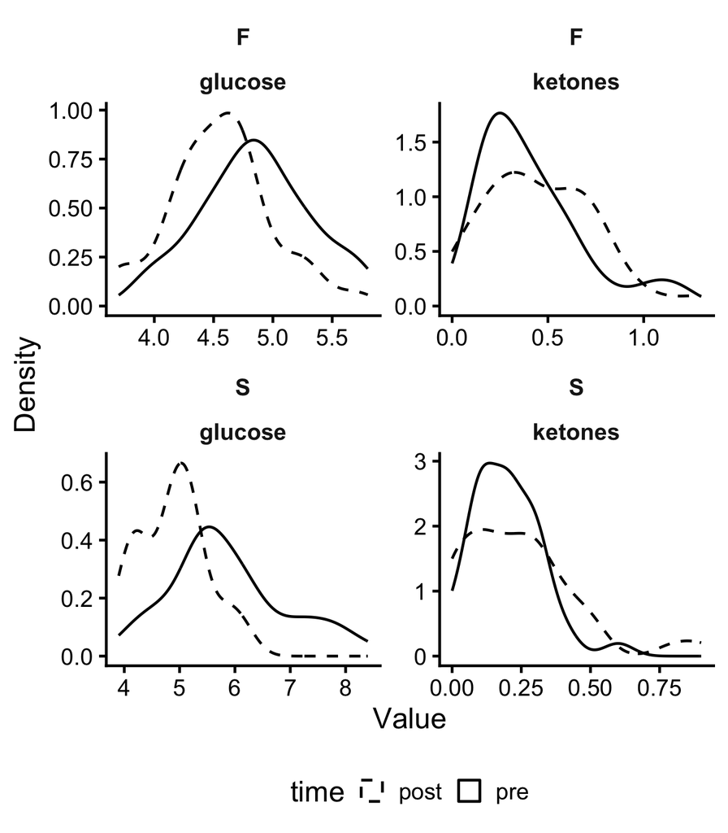

```
# A tibble: 1 × 4
  metabolic_state_s_f marker  time  value
  <chr>               <chr>   <chr> <dbl>
1 S                   ketones pre      NA
```

### 4.2.1 Planned condition

**Conditions overall (planned):**

| planned_condition | n |
| --- | --- |
| fasted | 36 |
| satiated | 39 |

**Conditions per session (planned):**

| session | planned_condition | n |
| --- | --- | --- |
| T1 | fasted | 22 |
| T1 | satiated | 21 |
| T2 | fasted | 14 |
| T2 | satiated | 18 |

planned_condition: a table containing the randomized condition, i.e., what was specified in the design.

## 4.3 Condition check

Randomisation-Check: Check whether “fasted” and “satiated” occur roughly the same number of times in T1 and T2.

| session | planned_condition | n |
| --- | --- | --- |
| T1 | fasted | 22 |
| T1 | satiated | 21 |
| T2 | fasted | 14 |
| T2 | satiated | 18 |

| planned_condition | session | n | prop |
| --- | --- | --- | --- |
| fasted | T1 | 22 | 0.6111111 |
| fasted | T2 | 14 | 0.3888889 |
| satiated | T1 | 21 | 0.5384615 |
| satiated | T2 | 18 | 0.4615385 |

## 4.4 Blood markers

| support_class | n |
| --- | --- |
| conflict_tie_break_planned | 61 |
| support_fasted_only | 10 |
| support_satiated_only | 4 |

| n_sessions | n_support_fasted_only | n_support_satiated_only | n_conflict | n_no_support | perc_no_support |
| --- | --- | --- | --- | --- | --- |
| 75 | 10 | 4 | 61 | 0 | 0 |

### 4.4.1 Manipulation Check Condition and Blood

Aim: To verify whether the planned treatment group (randomization) corresponds to the biological classification (blood test results).

| planned_condition | measured_condition | n |
| --- | --- | --- |
| fasted | fasted | 36 |
| satiated | fasted | 1 |
| satiated | satiated | 38 |

| n_sessions | n_match | perc_match |
| --- | --- | --- |
| 75 | 74 | 98.66667 |

| match | n |
| --- | --- |
| false | 1 |
| true | 74 |

| fastress_id | session | planned_condition | measured_condition |
| --- | --- | --- | --- |
| sub-019 | T1 | satiated | satiated |
| sub-007 | T1 | satiated | satiated |
| sub-005 | T1 | satiated | satiated |
| sub-022 | T1 | satiated | satiated |
| sub-054 | T1 | fasted | fasted |
| sub-039 | T1 | satiated | satiated |
| sub-084 | T1 | satiated | satiated |
| sub-083 | T1 | fasted | fasted |
| sub-003 | T1 | fasted | fasted |
| sub-017 | T1 | satiated | satiated |
| sub-016 | T1 | satiated | satiated |
| sub-018 | T1 | fasted | fasted |
| sub-033 | T1 | fasted | fasted |
| sub-038 | T1 | satiated | satiated |
| sub-042 | T1 | fasted | fasted |
| sub-006 | T1 | satiated | satiated |
| sub-004 | T1 | fasted | fasted |
| sub-009 | T1 | fasted | fasted |
| sub-027 | T1 | satiated | satiated |
| sub-032 | T1 | fasted | fasted |
| sub-031 | T1 | satiated | satiated |
| sub-028 | T1 | fasted | fasted |
| sub-041 | T1 | satiated | satiated |
| sub-050 | T1 | fasted | fasted |
| sub-072 | T1 | fasted | fasted |
| sub-015 | T1 | satiated | satiated |
| sub-024 | T1 | fasted | fasted |
| sub-044 | T1 | fasted | fasted |
| sub-013 | T1 | satiated | satiated |
| sub-010 | T1 | satiated | satiated |
| sub-051 | T1 | fasted | fasted |
| sub-008 | T1 | fasted | fasted |
| sub-025 | T1 | satiated | satiated |
| sub-012 | T1 | fasted | fasted |
| sub-007 | T2 | fasted | fasted |
| sub-002 | T2 | fasted | fasted |
| sub-003 | T2 | satiated | satiated |
| sub-008 | T2 | satiated | satiated |
| sub-009 | T2 | satiated | satiated |
| sub-015 | T2 | fasted | fasted |
| sub-024 | T2 | satiated | satiated |
| sub-020 | T2 | satiated | satiated |
| sub-018 | T2 | satiated | satiated |
| sub-019 | T2 | fasted | fasted |
| sub-022 | T2 | fasted | fasted |
| sub-051 | T2 | satiated | satiated |
| sub-004 | T2 | satiated | satiated |
| sub-053 | T2 | fasted | fasted |
| sub-054 | T2 | satiated | satiated |
| sub-027 | T2 | fasted | fasted |
| sub-025 | T2 | satiated | satiated |
| sub-029 | T2 | satiated | satiated |
| sub-030 | T2 | satiated | satiated |
| sub-031 | T2 | satiated | satiated |
| sub-028 | T2 | satiated | satiated |
| sub-023 | T2 | satiated | satiated |
| sub-017 | T2 | fasted | fasted |
| sub-038 | T2 | fasted | fasted |
| sub-039 | T2 | fasted | fasted |
| sub-042 | T2 | satiated | satiated |
| sub-050 | T2 | satiated | satiated |

**planned_condition** = Design variable (randomization) -> for primary analyses

**blood_condition** = Compliance/manipulation check -> for validation condition_check = Documentation of whether the manipulation actually worked

==> Perform all primary analyses using planned_condition.

Show all sessions that do not match:

| fastress_id | session | planned_condition | measured_condition |
| --- | --- | --- | --- |
| sub-002 | T1 | satiated | fasted |

| planned_condition | n_sessions | ketones_pre_M | ketones_pre_SD | glucose_pre_M | glucose_pre_SD |
| --- | --- | --- | --- | --- | --- |
| fasted | 36 | 0.4138889 | 0.2748015 | 4.855556 | 0.4711351 |
| satiated | 39 | 0.1973684 | 0.1240899 | 5.876923 | 1.0584153 |

# 5 Survey data

## 5.1 Survey import

```
# A tibble: 1 × 2
  n_rows n_unique_id
   <int>       <int>
1     43          43
```

```
# A tibble: 1 × 2
  n_rows n_unique_id
   <int>       <int>
1     32          32
```

```
# A tibble: 0 × 2
# ℹ 2 variables: fastress_id <chr>, n <int>
```

```
# A tibble: 0 × 2
# ℹ 2 variables: fastress_id <chr>, n <int>
```

```
# A tibble: 1 × 5
  fastress_id    id submitdate          startdate           datestamp
  <chr>       <dbl> <dttm>              <dttm>              <dttm>
1 sub-004        35 2026-03-10 11:37:44 2026-03-10 11:24:56 2026-03-10 11:37:44
```

sub-002 appears twice -> both are T1 -> keep the first one filled out

sub-004 filled out survey T2 twice -> we keep the one from 10.03. as this was her second session.

```
# A tibble: 0 × 2
# ℹ 2 variables: fastress_id <chr>, n <int>
```

```
# A tibble: 0 × 2
# ℹ 2 variables: fastress_id <chr>, n <int>
```

```
# A tibble: 0 × 5
# ℹ 5 variables: fastress_id <chr>, id <dbl>, submitdate <dttm>,
#   startdate <dttm>, datestamp <dttm>
```

```
# A tibble: 0 × 5
# ℹ 5 variables: fastress_id <chr>, id <dbl>, submitdate <dttm>,
#   startdate <dttm>, datestamp <dttm>
```

## 5.2 Survey merge

```
[1] "character"
```

```
[1] "character"
```

```
# A tibble: 2 × 2
  session     n
  <chr>   <int>
1 T1         43
2 T2         32
```

```
# A tibble: 0 × 3
# ℹ 3 variables: fastress_id <chr>, session <chr>, n <int>
```

## 5.3 Hunger ratings

```
[1] "hunger_hunger" "hunger_time"
```

```
[1] "hunger_hunger" "hunger_time"
```

```
# A tibble: 1 × 3
  n_rows n_ids n_nonmiss_hunger
   <int> <int>            <int>
1     75    43               75
```

```
# A tibble: 0 × 3
# ℹ 3 variables: fastress_id <chr>, session <chr>, n <int>
```

## 5.4 Trait scoring (T1 & T2)

```
                sses stadit_trait_anxiety                 cerq
                  10                    5                   27
      edeq_restraint
                   5
```

### 5.4.1 Reverse scoring

```
 [1] "srs3_srs3"   "srs6_srs6"   "srs10_srs10" "srs11_srs11" "srs12_srs12"
 [6] "srs14_srs14" "srs15_srs15" "srs17_srs17" "srs19_srs19" "srs21_srs21"
[11] "srs22_srs22" "srs23_srs23" "srs24_srs24" "srs25_srs25" "srs28_srs28"
```

```
# A tibble: 29 × 3
   item        min_raw max_raw
   <chr>         <dbl>   <dbl>
 1 srs10_srs10       1       3
 2 srs11_srs11       1       3
 3 srs12_srs12       1       3
 4 srs13_srs13       1       3
 5 srs14_srs14       2       3
 6 srs15_srs15       1       3
 7 srs16_srs16       1       3
 8 srs17_srs17       1       3
 9 srs18_srs18       1       3
10 srs19_srs19       1       3
# ℹ 19 more rows
```

```
# A tibble: 3 × 2
  srs14_srs14     n
  <chr>       <int>
1 <NA>           43
2 3              23
3 2               9
```

```
# A tibble: 4 × 2
  srs17_srs17     n
  <chr>       <int>
1 <NA>           43
2 2              21
3 1              10
4 3               1
```

```
# A tibble: 1 × 29
  srs1_srs1 srs2_srs2 srs3_srs3 srs4_srs4 srs5_srs5 srs6_srs6 srs7_srs7
      <int>     <int>     <int>     <int>     <int>     <int>     <int>
1        43        43        43        43        43        43        43
# ℹ 22 more variables: srs8_srs8 <int>, srs9_srs9 <int>, srs10_srs10 <int>,
#   srs11_srs11 <int>, srs12_srs12 <int>, srs13_srs13 <int>, srs14_srs14 <int>,
#   srs15_srs15 <int>, srs16_srs16 <int>, srs17_srs17 <int>, srs18_srs18 <int>,
#   srs19_srs19 <int>, srs20_srs20 <int>, srs21_srs21 <int>, srs22_srs22 <int>,
#   srs23_srs23 <int>, srs24_srs24 <int>, srs25_srs25 <int>, srs26_srs26 <int>,
#   srs27_srs27 <int>, srs28_srs28 <int>, srs29_srs29 <int>
```

```
# A tibble: 75 × 4
   fastress_id session srs14_srs14 srs17_srs17
   <chr>       <chr>   <chr>       <chr>
 1 sub-001     T1      <NA>        <NA>
 2 sub-001     T2      2           2
 3 sub-002     T1      <NA>        <NA>
 4 sub-002     T2      2           2
 5 sub-003     T1      <NA>        <NA>
 6 sub-003     T2      3           2
 7 sub-004     T1      <NA>        <NA>
 8 sub-004     T2      3           2
 9 sub-005     T1      <NA>        <NA>
10 sub-005     T2      3           2
# ℹ 65 more rows
```

```
# A tibble: 7 × 3
  raw   recoded     n
  <chr>   <dbl> <int>
1 AO02        1    23
2 AO03        2     9
3 AO04        3     6
4 AO05        4     2
5 AO06        5     2
6 AO08        7     1
7 <NA>       NA    32
```

```
# A tibble: 5 × 4
  item             n_nonmiss min_recoded max_recoded
  <chr>                <int>       <dbl>       <dbl>
1 edeq01to12_edeq1        43           1           7
2 edeq01to12_edeq2        43           1           4
3 edeq01to12_edeq3        43           1           7
4 edeq01to12_edeq4        43           1           7
5 edeq01to12_edeq5        43           1           7
```

```
# A tibble: 32 × 3
   item             raw       n
   <chr>            <chr> <int>
 1 edeq01to12_edeq1 AO02     23
 2 edeq01to12_edeq1 AO03      9
 3 edeq01to12_edeq1 AO04      6
 4 edeq01to12_edeq1 AO05      2
 5 edeq01to12_edeq1 AO06      2
 6 edeq01to12_edeq1 AO08      1
 7 edeq01to12_edeq1 <NA>     32
 8 edeq01to12_edeq2 AO02     36
 9 edeq01to12_edeq2 AO03      6
10 edeq01to12_edeq2 AO05      1
# ℹ 22 more rows
```

### 5.4.2 Scale scoring

```
# A tibble: 2 × 8
  session n_rows n_srs n_sses n_cerq_adapt n_cerq_mal n_stadit n_edeq
  <chr>    <int> <int>  <int>        <int>      <int>    <int>  <int>
1 T1          43     0     43            0          0       43     43
2 T2          32    32      0           32         32       32      0
```

```
# A tibble: 2 × 5
  session srs_min srs_max srs_mean_overall srs_sd
  <chr>     <dbl>   <dbl>            <dbl>  <dbl>
1 T1       Inf    -Inf              NaN    NA
2 T2         1.14    2.62             1.92  0.356
```

```
# A tibble: 1 × 7
  n_persons n_srs n_sses n_cerq_adapt n_cerq_mal n_stadit n_edeq
      <int> <int>  <int>        <int>      <int>    <int>  <int>
1        43    32     43           32         32       43     43
```

```
[1] "fastress_id"           "session"               "srs_mean"
[4] "sses_mean"             "cerq_adaptive_mean"    "cerq_maladaptive_mean"
[7] "stadit_trait_anxiety"  "edeq_restraint"
```

# 6 Sample description

## 6.1 Education and sex

```
# A tibble: 3 × 3
  education_label                         n   prop
  <chr>                               <int>  <dbl>
1 Maturitaet oder Berufsmaturitaet       36 0.837
2 Universitaet Fachhochschule PH ETH      6 0.140
3 obligatorische Schule abgeschlossen     1 0.0233
```

```
# A tibble: 1 × 2
  n_persons n_missing_education
      <int>               <int>
1        43                   0
```

```
# A tibble: 2 × 3
  sex_label     n  prop
  <chr>     <int> <dbl>
1 maennlich    16 0.372
2 weiblich     27 0.628
```

```
# A tibble: 1 × 2
  n_persons n_missing_sex
      <int>         <int>
1        43             0
```

```
# A tibble: 43 × 4
   fastress_id education education_label                     sex_label
   <chr>           <dbl> <chr>                               <chr>
 1 sub-001            12 Universitaet Fachhochschule PH ETH  maennlich
 2 sub-002             8 Maturitaet oder Berufsmaturitaet    weiblich
 3 sub-003             2 obligatorische Schule abgeschlossen weiblich
 4 sub-004             8 Maturitaet oder Berufsmaturitaet    weiblich
 5 sub-005             8 Maturitaet oder Berufsmaturitaet    weiblich
 6 sub-006             8 Maturitaet oder Berufsmaturitaet    weiblich
 7 sub-007             8 Maturitaet oder Berufsmaturitaet    maennlich
 8 sub-008            12 Universitaet Fachhochschule PH ETH  maennlich
 9 sub-009             8 Maturitaet oder Berufsmaturitaet    weiblich
10 sub-010             8 Maturitaet oder Berufsmaturitaet    weiblich
# ℹ 33 more rows
```

## 6.2 Sample overview

**Result:** ids_food is a table with one column (fastress_id) and one row per person containing food data. The same applies to Blood and Survey. This is used to create three “participant lists.”

```
$food
[1] 43

$blood
[1] 43

$survey
[1] 43
```

## 6.3 Dataset overlap

-> Important: Who is in which dataset?

count combination:

```
# A tibble: 1 × 4
  in_food in_blood in_survey     n
  <lgl>   <lgl>    <lgl>     <int>
1 TRUE    TRUE     TRUE         43
```

Meaning: How many people are included in each combination?

Examples:  
TRUE TRUE TRUE = People with all three data sets  
TRUE TRUE FALSE = People with Food + Blood, but without Survey  
TRUE FALSE TRUE = Food + Survey, but no Blood

```
# A tibble: 0 × 1
# ℹ 1 variable: fastress_id <chr>
```

## 6.4 Sample Descriptives

Total sample (all with at least one valid session)

Analysis sample (only complete cases for within-subject models)

```
# A tibble: 3 × 2
  dataset n_persons
  <chr>       <int>
1 food           43
2 blood          43
3 survey         43
```

```
# A tibble: 1 × 4
  in_food in_blood in_survey     n
  <lgl>   <lgl>    <lgl>     <int>
1 TRUE    TRUE     TRUE         43
```

## 6.5 Demographics

```
# A tibble: 1 × 5
  n_persons age_M age_SD bmi_M bmi_SD
      <int> <dbl>  <dbl> <dbl>  <dbl>
1        43  21.4   2.62  21.7   2.43
```

```
# A tibble: 2 × 2
  sex_male_m_female_f     n
  <chr>               <int>
1 f                      27
2 m                      16
```

# 7 Build analysis dataset

## 7.1 Session merge

### 7.1.1 Food outcomes

- total_kcal → total energy intake
- high_kcal → energy from high-calorie snacks
- low_kcal → energy from low-calorie snacks
- prop_high_kcal → proportion of high-calorie energy (shift in preference under stress)

```
# A tibble: 6 × 2
  item          n
  <chr>     <int>
1 apple        75
2 cake         75
3 chips        75
4 chocolate    75
5 cracker      75
6 nuts         75
```

```
# A tibble: 1 × 2
  post_gt_pre     n
  <lgl>       <int>
1 FALSE         450
```

```
# A tibble: 1 × 3
  n_post_zero n_post_zero_with_pre n_post_zero_consumed_equals_pre
        <int>                <int>                           <int>
1          58                   58                              58
```

```
# A tibble: 58 × 7
   fastress_id session item    pre  post consumed_g consumed_g_clean
   <chr>       <chr>   <chr> <dbl> <dbl>      <dbl>            <dbl>
 1 sub-001     T1      apple   102     0        102              102
 2 sub-001     T2      apple   123     0        123              123
 3 sub-002     T1      apple   105     0        105              105
 4 sub-002     T2      apple   120     0        120              120
 5 sub-004     T1      apple   121     0        121              121
 6 sub-004     T2      apple   101     0        101              101
 7 sub-008     T1      apple   121     0        121              121
 8 sub-013     T1      apple   120     0        120              120
 9 sub-015     T2      apple   103     0        103              103
10 sub-022     T1      apple   148     0        148              148
# ℹ 48 more rows
```

```
# A tibble: 1 × 2
  n_pre_na n_post_na
     <int>     <int>
1        0         0
```

```
# A tibble: 0 × 7
# ℹ 7 variables: fastress_id <chr>, session <chr>, item <chr>, pre <dbl>,
#   post <dbl>, consumed_g <dbl>, consumed_g_clean <dbl>
```

```
# A tibble: 6 × 4
  item      pre_min pre_max pre_sd
  <chr>       <dbl>   <dbl>  <dbl>
1 apple          95     177 15.9
2 cake           37      69  5.09
3 chips          30      39  2.25
4 chocolate      28      35  1.31
5 cracker        17      21  0.538
6 nuts           25      42  2.78
```

```
character(0)
```

```
# A tibble: 1 × 4
  n_missing_total_kcal n_missing_high_kcal n_missing_low_kcal n_zero_total_kcal
                 <int>               <int>              <int>             <int>
1                    0                   0                  0                 0
```

```
# A tibble: 1 × 1
  max_abs_diff
         <dbl>
1     1.14e-13
```

```
# A tibble: 1 × 2
  n_missing_kcal n_missing_type
           <int>          <int>
1              0              0
```

### 7.1.2 Merge QC:

All three outputs should be empty.

```
# A tibble: 0 × 3
# ℹ 3 variables: fastress_id <chr>, session <chr>, n <int>
```

```
# A tibble: 0 × 3
# ℹ 3 variables: fastress_id <chr>, session <chr>, n <int>
```

```
# A tibble: 0 × 2
# ℹ 2 variables: fastress_id <chr>, n <int>
```

## 7.2 Analysis session

**This is the main dataset:**

```
# A tibble: 1 × 3
  n_rows n_ids n_missing_condition
   <int> <int>               <int>
1     75    43                   0
```

```
# A tibble: 4 × 3
  session planned_condition     n
  <chr>   <chr>             <int>
1 T1      fasted               22
2 T1      satiated             21
3 T2      fasted               14
4 T2      satiated             18
```

**Check after joining `planned_condition` and `blood_all`**

- `n_rows` and `n_pairs` should be equal
- The second output must be empty

```
# A tibble: 1 × 3
  n_rows n_ids n_pairs
   <int> <int>   <int>
1     75    43      75
```

```
# A tibble: 0 × 3
# ℹ 3 variables: fastress_id <chr>, session <chr>, n <int>
```

## 7.3 Trait merge

-> in analysis_session + Zentrierung

```
[1] "fastress_id"           "srs_mean"              "sses_mean"
[4] "stadit_trait_anxiety"  "edeq_restraint"        "cerq_adaptive_mean"
[7] "cerq_maladaptive_mean"
```

```
 [1] "fastress_id"           "session"               "total_kcal"
 [4] "high_kcal"             "low_kcal"              "prop_high_kcal"
 [7] "planned_condition"     "ketones_pre"           "glucose_pre"
[10] "ketones_post"          "glucose_post"          "hunger_hunger"
[13] "srs_mean"              "sses_mean"             "stadit_trait_anxiety"
[16] "edeq_restraint"        "cerq_adaptive_mean"    "cerq_maladaptive_mean"
[19] "subject"               "srs_c"                 "sses_c"
[22] "cerq_adaptive_c"       "cerq_maladaptive_c"    "stadit_c"
[25] "edeq_restraint_c"
```

```
# A tibble: 1 × 7
  total_kcal_type high_kcal_type low_kcal_type prop_high_kcal_type
  <chr>           <chr>          <chr>         <chr>
1 numeric         numeric        numeric       numeric
# ℹ 3 more variables: ketones_pre_type <chr>, glucose_pre_type <chr>,
#   srs_type <chr>
```

```
# A tibble: 1 × 4
  n_ids n_srs n_sses n_stadit
  <int> <int>  <int>    <int>
1    43    64     75       75
```

### 7.3.1 Merge QC

- n_rows and n_pairs should be equal
- The second output must be empty

```
# A tibble: 1 × 3
  n_rows n_ids n_pairs
   <int> <int>   <int>
1     75    43      75
```

```
# A tibble: 0 × 3
# ℹ 3 variables: fastress_id <chr>, session <fct>, n <int>
```

## 7.4 Missingness Reporting

### 7.4.1 Session missingness

```
# A tibble: 1 × 13
  n_rows n_ids n_missing_planned_condition n_missing_total_kcal
   <int> <int>                       <int>                <int>
1     75    43                           0                    0
# ℹ 9 more variables: n_missing_prop_high_kcal <int>,
#   n_missing_ketones_pre <int>, n_missing_glucose_pre <int>,
#   n_missing_srs <int>, n_missing_sses <int>, n_missing_stadit <int>,
#   n_missing_edeq <int>, n_missing_cerq_adaptive <int>,
#   n_missing_cerq_maladaptive <int>
```

### 7.4.2 Person missingness

```
# A tibble: 2 × 2
  n_sessions     n
       <int> <int>
1          1    11
2          2    32
```

```
# A tibble: 1 × 3
  n_rows n_ids n_sessions
   <int> <int>      <int>
1     64    32          2
```

## 7.5 Analysis samples

```
# A tibble: 1 × 4
  n_rows n_sessions n_conditions     n
   <int>      <int>        <int> <int>
1      2          2            2    30
```

# 8 Save cleaned datasets

```
Cleaning file rendered at: 1776584255
```